# 1.2 Visuelle Odometrie

ORB-SLAM3 — Kamerabewegung aus Bildsequenzen

Autor:in

Nediljko Andrijanic

Veröffentlichungsdatum

11. Mai 2026

## Agenda

Diese Vorlesung behandelt **Schritte 8–12** des ORB-SLAM3-Algorithmus:

- **Schritt 8:** ORB Patch & Orientierung — Aussehen des Features bestimmen
- **Schritt 9:** Binärer Deskriptor — 256-Bit Fingerabdruck
- **Schritt 10:** Feature Matching — Features zwischen Frames vergleichen
- **Schritt 11:** Pose-Schätzung — Kamerabewegung berechnen
- **Schritt 12:** Trajektorie — Kamera-Pfad über Zeit

**Ziel:** Aus zwei Bildframes → Rotation R und Translation t der Kamera ermitteln.

## 1.2 Visuelle Odometrie — Pipeline

```
graph LR
    A["Keypoints<br/>(x, y)"]
    B["8: ORB Patch<br/>+ Orientierung"]
    C["(x, y, θ)"]
    D["9: Binärer<br/>Deskriptor"]
    E["256-Bit<br/>Fingerabdruck"]
    F["10: Feature<br/>Matching"]
    G["Gematchte<br/>Paare"]
    H["11: Essential<br/>Matrix"]
    I["R, t<br/>(Pose)"]
    J["12: Trajektorie<br/>Akkumulation"]
    K["Kamera-Pfad"]

    A -->|Frame t| B --> C --> D --> E
    E -->|Frame t + Frame t+1| F --> G --> H --> I --> J --> K
    A -->|Frame t+1| B --> C --> D --> E

    style B fill:#3a5f3a
    style D fill:#3a5f3a
    style F fill:#3a5f3a
    style H fill:#3a5f3a
    style J fill:#3a5f3a
```

## Wo stehen wir?

Nach **Schritt 7** (Harris Score) haben wir für **jeden Frame**: - N Keypoints mit ihren **Positionen (x, y)** - Diese sind gleichmäßig verteilt (Quadtree) und qualitätsgeprüft (Harris)

**Problem:** Wir kennen WO die Ecken sind, aber nicht WIE sie aussehen.

**Frage:** Wenn Frame 1 dieselbe Ecke wie Frame 0 hat, wie erkennen wir das? - Kann nicht einfach Nachbarschaft vergleichen — die Ecke sieht in Frame 1 anders aus (andere Position, Winkel, Helligkeit)

**Lösung:** Wir extrahieren einen **Fingerabdruck** (Deskriptor) pro Feature — ein kompaktes Merkmal das **robust gegen Transformationen** ist.

## Schritt 8: ORB Patch & Orientierung — Theorie

**Eingang:** Keypoint-Position (x,y) pro Frame → **Ausgang → Schritt 9:** Patch + Orientierungswinkel θ

**Problem:** Eine Ecke sieht unterschiedlich aus, je nachdem aus welchem Winkel wir sie sehen.

```
Beispiel:
┌─┐           Gedreht 45°:    Gedreht 90°:
│▓│           ╱▓╲             ──▓──
└─┘           ▓ ▓             │▓▓▓│
              ╲▓╱             └─┘

Selbe Ecke, aber visuell verschiedene Nachbarschaften
→ Wenn wir direkt vergleichen, merken wir nicht dass es dieselbe ist!
```

**Lösung — zwei Schritte:**

1. **Patch extrahieren:** Schneide ein 31×31 Fenster um die Keypoint-Position
2. **Orientierung berechnen:** Berechne den dominanten Winkel θ mittels Intensity Centroid Method

**Orientierung (Intensity Centroid):**

$$\theta = \text{atan2}(m_{01}, m_{10})$$

wobei $m_{pq} = \sum_{x,y \in \text{Patch}} x^p y^q \cdot I(x,y)$ die räumlichen Momente sind.

**Interpretation:** θ ist die Richtung vom Patchzentrum zum “hellsten Bereich”. Wenn wir beide Patches auf dieselbe Orientierung drehen (Rotation um θ), sehen sie gleich aus.

**Warum wichtig:** - Ohne Orientierung: Deskriptor von Frame 0 (Winkel 0°) ≠ Deskriptor von Frame 1 (Winkel 45°) - Mit Orientierung: Wir drehen beide auf θ=0° → gleicher Deskriptor → Erkennung funktioniert

## Schritt 8: ORB Patch & Orientierung — Beispiel 1: Echtes Bild

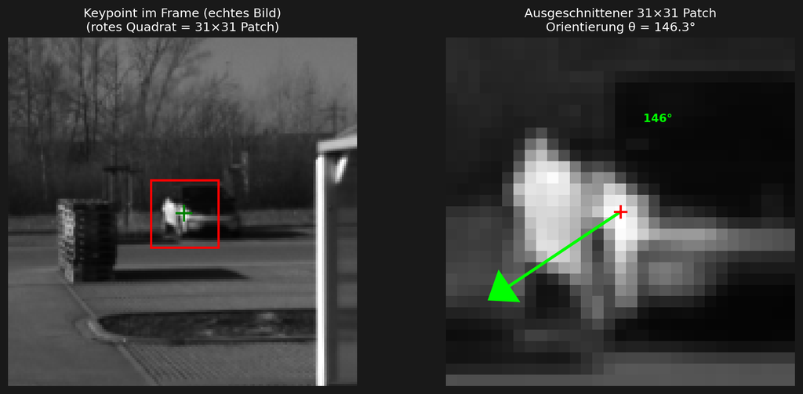

## Schritt 8: ORB Patch & Orientierung — Beispiel 2: Dieselbe Ecke in 2 Frames mit VERSCHIEDENEN Orientierungen

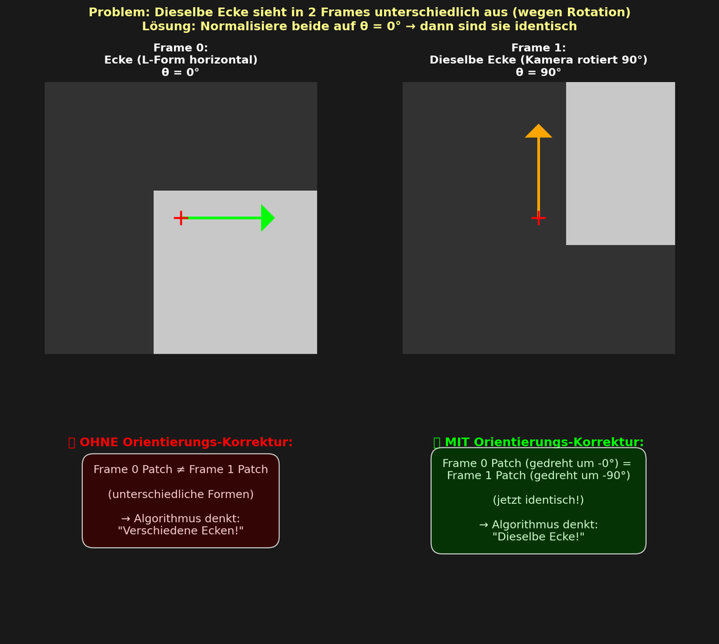

## Schritt 8: ORB Patch & Orientierung — Beispiel 3: Intensity Centroid erklärt

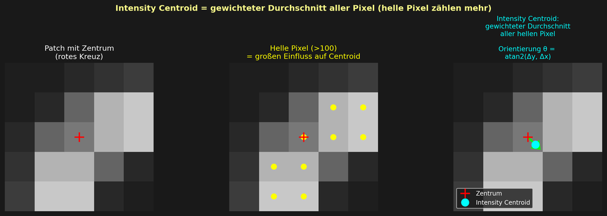

## Schritt 8: ORB Patch & Orientierung — Warum ist das wichtig?

**Ohne Orientierungs-Normalisierung:**

```
Frame 0: Feature θ = 0°  → Patch-Pixel-Nachbarschaft A
Frame 1: Feature θ = 45° → Patch-Pixel-Nachbarschaft B

A ≠ B (weil nur gedreht, nicht derselbe!)
→ Algorithmus denkt: "Verschiedene Ecken!"
→ FALSCH — es ist dieselbe Ecke!
```

**Mit Orientierungs-Normalisierung:**

```
Frame 0: Feature θ = 0°  → Patch gedreht auf θ = 0° → Nachbarschaft A
Frame 1: Feature θ = 45° → Patch gedreht auf θ = 0° (Drehung um -45°) → Nachbarschaft A

A = A
→ Algorithmus denkt: "Dieselbe Ecke!"
→ RICHTIG!
```

**Das ist die Kraft von Schritt 8:** - Erkennt nicht nur WO eine Ecke ist (x, y) - Sondern auch IN WELCHER ORIENTIERUNG sie ist (θ) - Und normalisiert alle Patches auf dieselbe Orientierung - → Robustes Feature-Matching über Frames hinweg

**Ergebnis:** Jeder Keypoint hat jetzt **(x, y, θ)** — Position UND Orientierung.

## Schritt 8: ORB Patch & Orientierung — Beispiel 4: 6 echte Frames

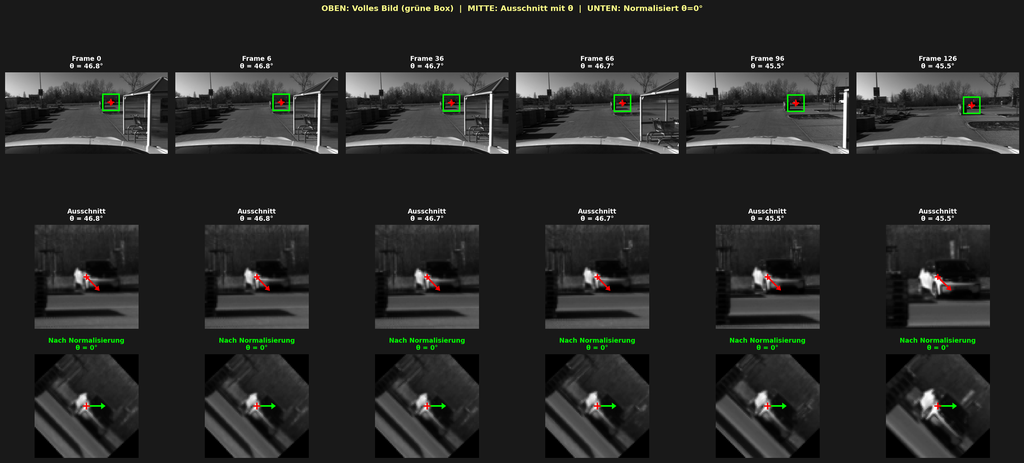

## Schritt 9: Binärer Deskriptor — Theorie

**Eingang:** Patch + Orientierung θ → **Ausgang → Schritt 10:** 256-Bit Fingerabdruck

**Ziel:** Komprime den Patch zu einer 256-Bit Binärzahl die: - Schnell zu berechnen ist (für Echtzeit) - Schnell zu vergleichen ist (Hamming-Distanz statt Pixelweise Differenz) - Robust gegen kleine Transformationen (Rauschen, Helligkeit)

**Algorithmus (BRIEF-Test nach Rotation):**

1. Definiere **256 Pixelpaare** (A, B) im Patch mit festen Positionen
   - **Entscheidend:** Diese 256 Paare sind **für ALLE Bilder identisch** (einmal vom ORB-Designer optimiert und dann unveränderlich)
   - Nur deshalb ist der Hamming-Vergleich zweier Deskriptoren möglich und sinnvoll!
2. **Für jedes Paar:** Berechne $\text{Bit}_i = (I_A < I_B) ? 1 : 0$
3. **Ergebnis:** Vektor von 256 Bits = eindeutiger Fingerabdruck

**Beispiel mit 4 Paaren (vereinfacht):**

| Paar | Position A | Position B | $I_A$ | $I_B$ | $I_A < I_B$ | Bit |
| --- | --- | --- | --- | --- | --- | --- |
| 1 | (5,5) | (10,5) | 180 | 200 | ✓ | **1** |
| 2 | (15,15) | (8,8) | 120 | 140 | ✓ | **1** |
| 3 | (3,10) | (12,3) | 160 | 150 | ✗ | **0** |
| 4 | (20,10) | (15,15) | 100 | 120 | ✓ | **1** |

→ **4-Bit Deskriptor:** `1101`

## Schritt 9: Binärer Deskriptor — Beispiel 1: Schritt für Schritt

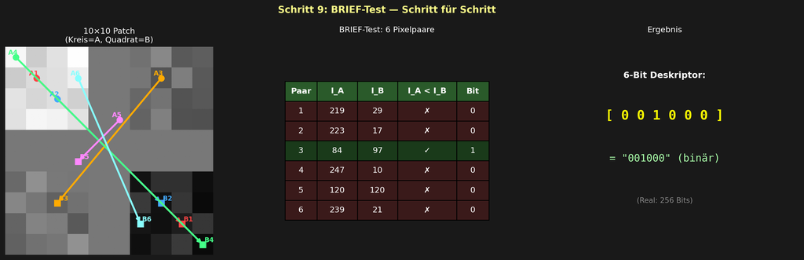

## Schritt 9: Binärer Deskriptor — Beispiel 2: Dieselbe Ecke aus 6 Frames

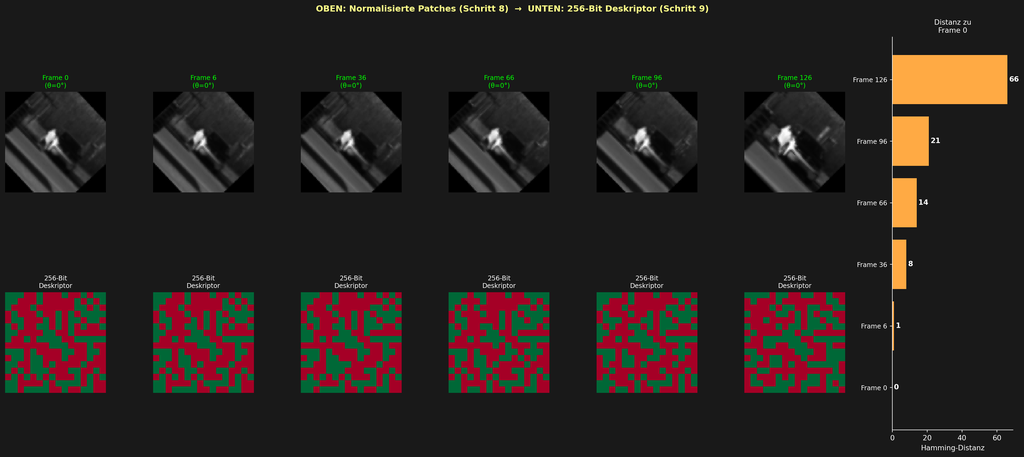

## Schritt 10: Feature Matching — Theorie

**Eingang:** Deskriptoren Frame t + Deskriptoren Frame t+1 → **Ausgang → Schritt 11:** gematchte Paare

**Problem:** Wir haben 500 Features in Frame 0 und 500 in Frame 1. Welche gehören zusammen?

**Lösung:** Vergleiche Deskriptoren mit **Hamming-Distanz**.

**Hamming-Distanz:**

Zwei 256-Bit Deskriptoren $D_1$ und $D_2$:
$$d_H(D_1, D_2) = \text{popcount}(D_1 \oplus D_2)$$

$\oplus$ = bitweises XOR popcount = Anzahl der 1-Bits

**Interpretation:** - $d_H = 0$ → identisch → **sehr ähnlich** - $d_H = 10$ → **ähnlich** - $d_H = 128$ → **unähnlich**

**Lowe’s Ratio Test:**

$$\frac{d_{\text{best}}}{d_{\text{2nd-best}}} < 0.75$$

Verwerfe Matches die nicht klar sind.

## Schritt 10: Feature Matching — Beispiel

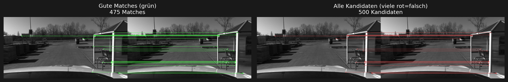

## Schritt 10: Feature Matching — Beispiel 2: Dieselbe Ecke aus 6 Frames

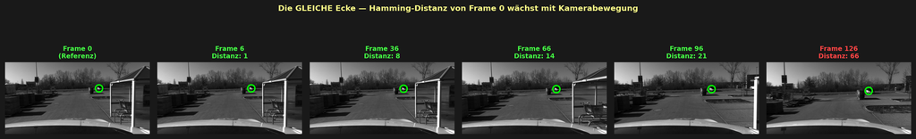

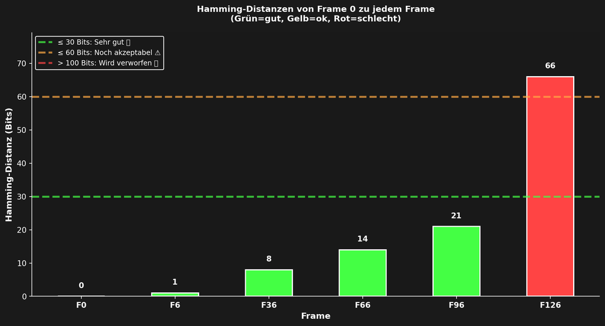

```
📊 Hamming-Distanz für EINE Ecke über 6 Frames:
  • Frame 0 → Distanz   0 Bits ✅ Sehr gut
  • Frame 6 → Distanz   1 Bits ✅ Sehr gut
  • Frame 36 → Distanz   8 Bits ✅ Sehr gut
  • Frame 66 → Distanz  14 Bits ✅ Sehr gut
  • Frame 96 → Distanz  21 Bits ✅ Sehr gut
  • Frame 126 → Distanz  66 Bits ❌ Zu weit

→ Je weiter die Kamera sich bewegt, desto größer die Hamming-Distanz!
```

**Wichtig — Vergleich mit welchem Frame?**

**Im echten ORB-SLAM3 werden stattdessen konsekutive Frames verglichen:** - Frame 0 → Frame 6: kleine Distanz (Kamera wenig bewegt) - Frame 6 → Frame 36: kleine Distanz (wieder wenig bewegt) - …und so weiter

Das macht mehr Sinn, weil sich die Kamera zwischen zwei aufeinanderfolgenden Frames nur **minimal** bewegt → die Ecken sehen sich sehr ähnlich → stabile, robuste Matches.

## Schritt 11: Pose-Schätzung — Theorie

**Eingang:** gematchte Punktpaare → **Ausgang → Schritt 12:** Rotation R und Translation t

**Ziel:** Aus ≥5 Pointpaaren → Kamerabewegung

**Essential Matrix:**

$$x'^T E x = 0$$

Zerlegen mit SVD → R, t

**RANSAC:** Ignoriere Ausreißer durch Iteration

**Schritt für Schritt:**

1. **Eingabe:** Mindestens 5 gematchte Punktpaare $(x_i, x'_i)$ aus Schritt 10 (Koordinaten im Bild)
2. **Essential Matrix E berechnen:** Basiert auf epipolar geometry — der mathematischen Beziehung zwischen zwei Kamerasichten
   - `cv2.findEssentialMat` mit RANSAC findet die beste E, die zu den meisten Punkten passt (Ausreißer werden ignoriert)
3. **R und t aus E extrahieren:** Die Essential Matrix wird per SVD zerlegt → ergibt Rotation R und Translation t
   - R = wie viel die Kamera gedreht hat
   - t = wie viel die Kamera verschoben hat
4. **Ausgabe:** R ∈ SO(3) (3×3 Rotationsmatrix), t ∈ ℝ³ (3D Translationsvektor)

## Schritt 11: Pose-Schätzung — Beispiel: Alle 5 Konsekutiv-Paare aus 6 Frames

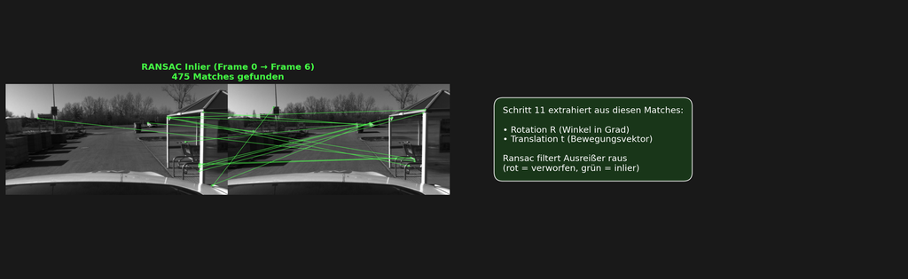

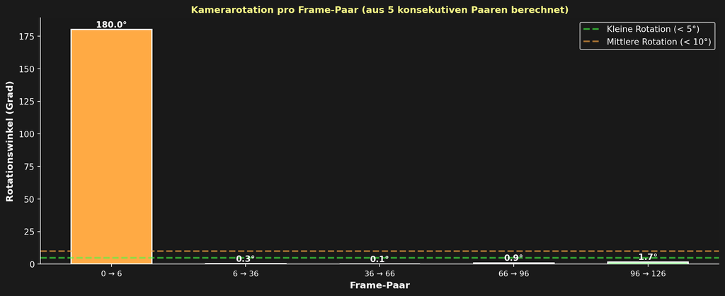

```
📊 Kamerabewegung aus 5 Frame-Paaren:
  • 0 → 6: Rotation 180.00°
  • 6 → 36: Rotation 0.29°
  • 36 → 66: Rotation 0.11°
  • 66 → 96: Rotation 0.91°
  • 96 → 126: Rotation 1.68°
```

## Schritt 12: Trajektorie

**Eingang:** R, t pro Frame → **Ausgang (1.2 fertig):** Kamera-Trajektorie

**Akkumulation der Posen:**

$$P_i = P_{i-1} + R_{i-1}^T \cdot t_i$$

**Schritt für Schritt:**

1. **Startposition:** Kamera bei Ursprung $(0, 0, 0)$, Orientierung = Identität (keine Rotation)
2. **Loop über alle Frame-Paare:** Für jedes Paar $(F_i, F_{i+1})$:
   - Berechne $R_i, t_i$ aus Schritt 11
   - Neue Position: $P_{i+1} = P_i + R_i^T \cdot t_i$ (Verschiebung in Kamera-Koordinaten)
   - Neue Orientierung: $R_\text{neu} = R_\text{alt} \cdot R_i$ (Rotationen kombinieren)
3. **Ausgabe:** Satz von Positionen $\{P_0, P_1, P_2, ..., P_N\}$ — die **Kamera-Trajektorie**

**Wichtig — Drift:** - Kleine Fehler in jedem $(R_i, t_i)$ akkumulieren sich → über viele Frames wird die Trajektorie immer ungenauer - Das ist der Grund für Loop Closure Detection und Bundle Adjustment in echtem ORB-SLAM3

## Schritt 12: Trajektorie — Beispiel

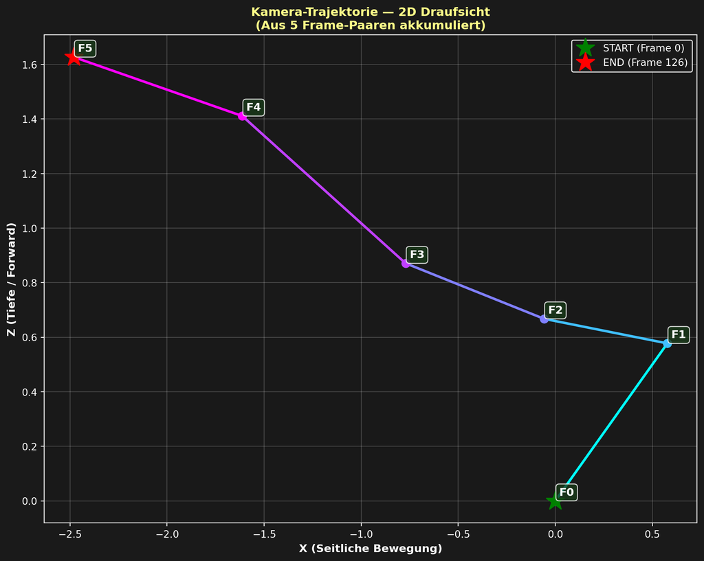

```
📍 Kamera-Trajektorie über 6 Frames:
  • Frame 0: Position (0.000, 0.000, 0.000)
  • Frame 6: Position (0.577, -0.577, 0.577)
  • Frame 36: Position (-0.058, 0.189, 0.668)
  • Frame 66: Position (-0.771, 0.861, 0.871)
  • Frame 96: Position (-1.613, 0.860, 1.411)
  • Frame 126: Position (-2.481, 1.307, 1.627)

→ Gesamtbahn: 5.000 Einheiten
→ Fehler akkumuliert sich über Zeit → das ist das Drift-Problem!
```

## Zusammenfassung 1.2

| Schritt | Algorithmus | Ergebnis |
| --- | --- | --- |
| 8 | Patch + Orientierung | (x, y, θ) |
| 9 | Binärer Deskriptor | 256-Bit Fingerabdruck |
| 10 | Hamming Matching | Gematchte Paare |
| 11 | Essential Matrix | R, t (Pose) |
| 12 | Pose-Akkumulation | **Kamera-Trajektorie** |